# Untitled

Iffy

Friday, July 16, 2021

```r
## Install pacman

if(!require(pacman)){

  install.packages("pacman")

}

## Load required packages- ensure internet connection to load the packages
pacman::p_load(tidyverse, tidymodels, skimr, janitor, Amelia, knitr, kableExtra,

               pglm, baguette, rpart.plot)
```

# 1 Background

## 1.1 Purpose of the study

The main objective of this study is to identify different the factors that influence misreporting of financial information amongst the top 40 Johannesburg Stock Exchange (JSE) listed firms. The presence of misreporting for firms listed on the JSE has been detected mostly by restatements firms have made through the Stock Exchange News Services (SENS), although this has not been the only way. Some firms may have wanted to perpetuate the misreporting for different reasons until the errors are exposed through media, rating agencies, whistle blowing, underground investigations, and so on. Rasyid and Ardana (2014) agreed with Ciesielski and Weirich (2006) that accounting complexities are the main drivers of most restatements. These restatements are the main triggers for firms presenting restated financial statements. The restated financial statements eventually lead to huge transaction costs emanating from the errors of the initial presentation. The errors mislead the interpretation of the state of the firm, which in turn influences the whole decision-making process in the stock market regarding appropriate capital and is thus misleading to investors at large.

## 1.2 Research questions

Flowing from the stated research problems, the following are the research questions for this study:

- Do equity incentives to executives influence financial misreporting?
- Does financial distress influence financial misreporting?
- Does poor internal corporate governance influence financial misreporting?
- Does family ownership influence financial misreporting?
- Does state ownership influence misreporting?

- Equity incentives to executives to encourage financial misreporting;
- Financial distress of a company influences financial misreporting;
- Poor internal corporate governance influences financial misreporting;
- Family ownership influences financial misreporting; and
- State ownership influences misreporting.

# 2 Data and variables definitions

Poor internal controls and corporate governance is made up of Penalties, qualified audit and separation of control were used to determine poor internal controls and corporate governance. Where either variable was in any given year it was marked by 1 and 0 when not found and a total score was given for that year with a minimum of 0 and max of 3.

## 2.1 Read in the Data

```r
iffy_data <- readxl::read_xlsx("data/iffy_data.xlsx") %>%

  janitor::clean_names() %>%

  select(name, company_code, year, restatements, family_b, eb,

         state_own, fin_ds, poor_corg) %>%

  mutate(restatements = factor(restatements),

         family_b = factor(family_b),

         eb = factor(eb),

         state_own = factor(state_own),

         fin_ds = factor(fin_ds),

         poor_corg = factor(poor_corg)
         )

head(iffy_data)
```

```
## # A tibble: 6 x 9
##   name   company_code  year restatements family_b eb    state_own fin_ds
##   <chr>  <chr>        <dbl> <fct>        <fct>    <fct> <fct>     <fct>
## 1 PROSUS PRX              1 0            0        1     0         0
## 2 PROSUS PRX              2 0            0        1     0         0
## 3 PROSUS PRX              3 0            0        1     0         0
## 4 PROSUS PRX              4 0            0        1     0         0
## 5 PROSUS PRX              5 0            0        1     0         0
## 6 PROSUS PRX              6 0            0        1     0         0
## # … with 1 more variable: poor_corg <fct>
```

# 3 Exploring the Data

## 3.1 Missing data

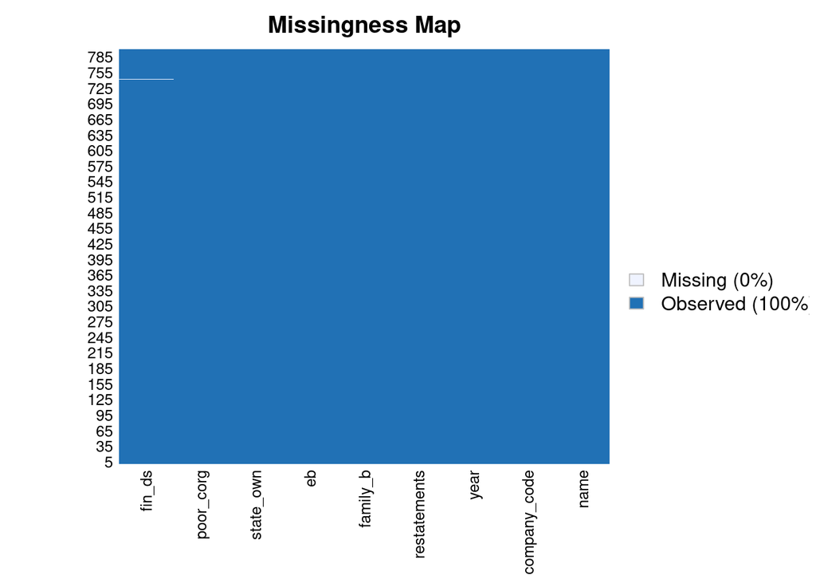

```r
## Graphing missing data
Amelia::missmap(iffy_data)
```

```r
## Count of missing data

sapply(iffy_data, is.na) %>%

  colSums() %>%

  tibble(VarNames = names(iffy_data), missing = .) %>%

  arrange(desc(missing)) %>%

  kableExtra::kbl(booktabs = TRUE, caption = "Missing Data") %>%

  kableExtra::kable_classic(full_width = FALSE)
```

Missing Data

| VarNames | missing |
| --- | --- |
| fin_ds | 1 |
| name | 0 |
| company_code | 0 |
| year | 0 |
| restatements | 0 |
| family_b | 0 |
| eb | 0 |
| state_own | 0 |
| poor_corg | 0 |

## 3.2 Data duplication

There are no duplicates

```r
iffy_data %>% filter(duplicated(.))
```

```
## # A tibble: 0 x 9
## # … with 9 variables: name <chr>, company_code <chr>, year <dbl>,
## #   restatements <fct>, family_b <fct>, eb <fct>, state_own <fct>,
## #   fin_ds <fct>, poor_corg <fct>
```

## 3.3 First we check the Dependent Variable

Here, we have an extreme case of class imbalance in the dependent variable, meaning we have very few restatements. See visualization on next page.

```r
table(iffy_data$restatements)
```

```
##
##   0   1
## 760  40
```

## 3.4 Data Visualisation

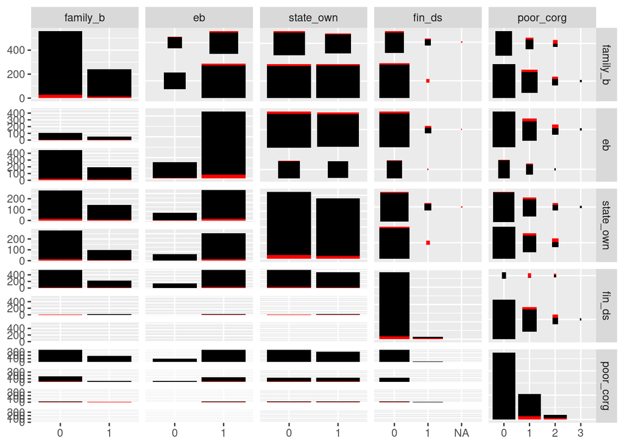

```r
iffy_data %>%

  GGally::ggpairs(columns = c("family_b", "eb", "state_own", "fin_ds", "poor_corg"),
                  mapping = aes(fill = restatements)
                  ) + scale_fill_manual(values = c("black", "red"))
```

# 4 The Models

## 4.1 First try panel logit model

- We fit a random effects panel logit model. It shows that the significant variables are financial distress and corporate governance.

```r
iffy_pglm <- pglm(restatements ~ family_b + eb + state_own + fin_ds + poor_corg,
           data = iffy_data,
           family = binomial("logit"), R = 5, print.level = 3,
           method = 'bfgs', index = c('company_code', 'year'),  model = "random")
```

```
## Initial function value: -112.1891
## Initial gradient value:
##   (Intercept)     family_b1           eb1    state_own1       fin_ds1
##  4.296996e+00  4.171236e+00  5.662097e+00  2.272641e+00  3.065357e+00
##    poor_corg1    poor_corg2    poor_corg3         sigma
##  3.827534e+00  3.699535e+00 -1.797644e-07 -3.681083e+00
```

```r
summary(iffy_pglm)
```

```
## --------------------------------------------
## Maximum Likelihood estimation
## BFGS maximization, 32 iterations
## Return code 0: successful convergence
## Log-Likelihood: -94.6342
## 9  free parameters
## Estimates:
##               Estimate Std. error t value  Pr(> t)
## (Intercept)   -7.68230    1.34541  -5.710 1.13e-08 ***
## family_b1      0.02711    0.82766   0.033    0.974
## eb1            0.39778    0.78725   0.505    0.613
## state_own1    -0.14441    0.66897  -0.216    0.829
## fin_ds1        4.52469    1.13707   3.979 6.91e-05 ***
## poor_corg1     4.38823    0.90178   4.866 1.14e-06 ***
## poor_corg2     6.07086    1.07941   5.624 1.86e-08 ***
## poor_corg3    -8.73391 3435.17815  -0.003    0.998
## sigma          2.54118    0.63259   4.017 5.89e-05 ***
## ---
## Signif. codes:  0 '***' 0.001 '**' 0.01 '*' 0.05 '.' 0.1 ' ' 1
## --------------------------------------------
```

## 4.2 The tree based model

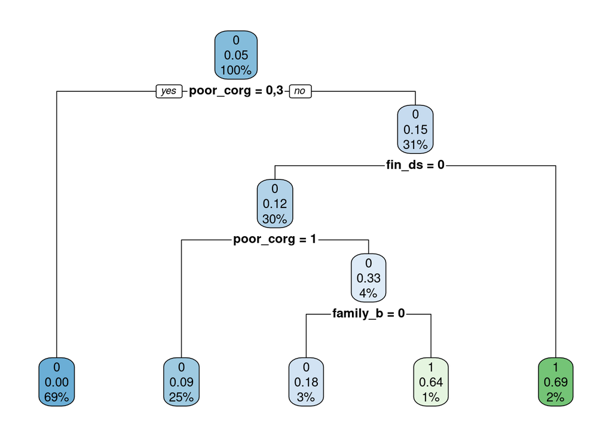

```r
## The model
iffy_decision_tree <- decision_tree() %>%

  set_mode("classification") %>%

  set_engine("rpart")

## Run the model

iffy_decision_regression <- workflow() %>%

  add_model(iffy_decision_tree) %>%

  add_formula(restatements ~ family_b + eb + state_own + fin_ds + poor_corg) %>%

  fit(data = iffy_data)

## Draw the tree

iffy_decision_plot <- iffy_decision_regression %>% extract_fit_parsnip()

rpart.plot(iffy_decision_plot$fit)
```

# 5 Way forward

- Attempt up sampling (bootstrap the data to make the dependent variable more balanced between companies that have restated versus those that have not restated) of the data to deal with the low prevalence of the companies that have restated.
- re run the models using the up sampled data.